# Cellen 2

Statistical thinking — exploratory data analysis

Gavin Simpson

gavin@anivet.au.dk

Aarhus University

2025-02-28

## Barcharts

Bar charts are a simple way of showing & comparing means or other values between groups of data

Top of the box is drawn at the data values you wish to plot, bottom at 0

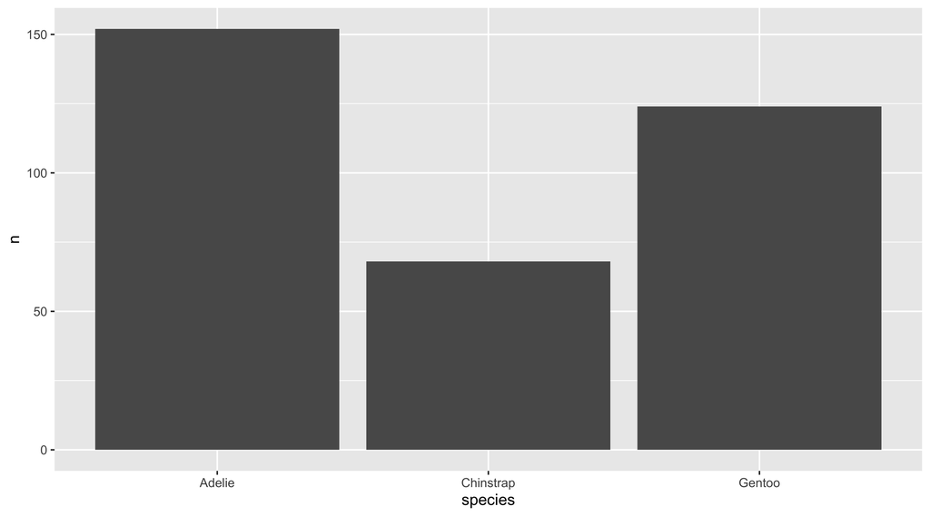

## Dotplots

However, barcharts are wasteful & often don’t focus on the real information you want to convey

Dotplots show the *same* information but focus on the difference in the variable plotted

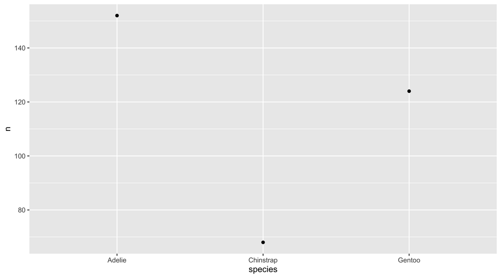

## Incorporating variability

Common to show a measure of spread or variability in dotplots or barcharts

Standard errors of means or confidence intervals usually more useful than standard deviations

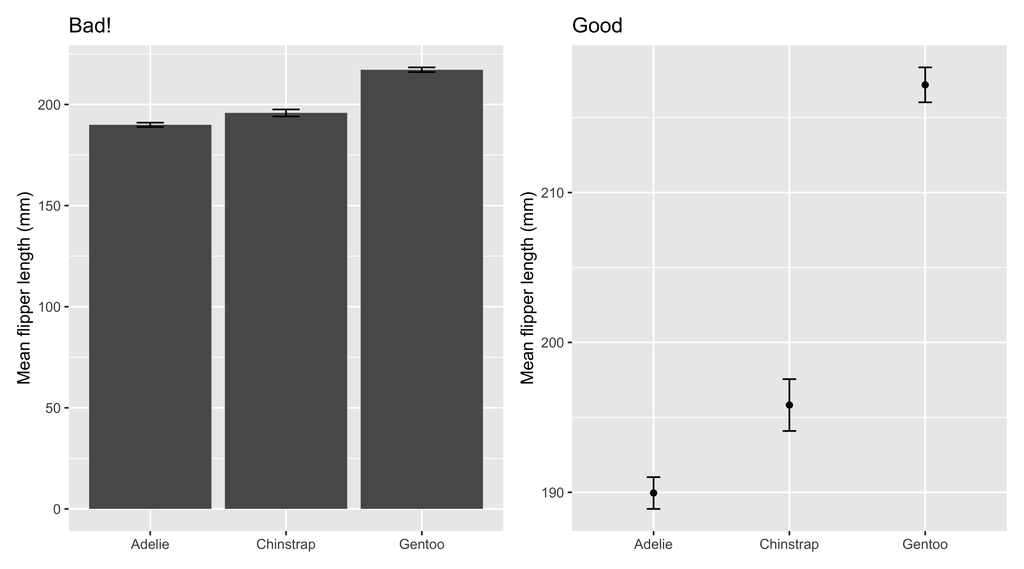

## Boxplots

A boxplot is a useful summary of samples with $n > 8$ observations

Shows the median, the upper and lower hinges & whiskers, plus any observations that lie beyond the whiskers

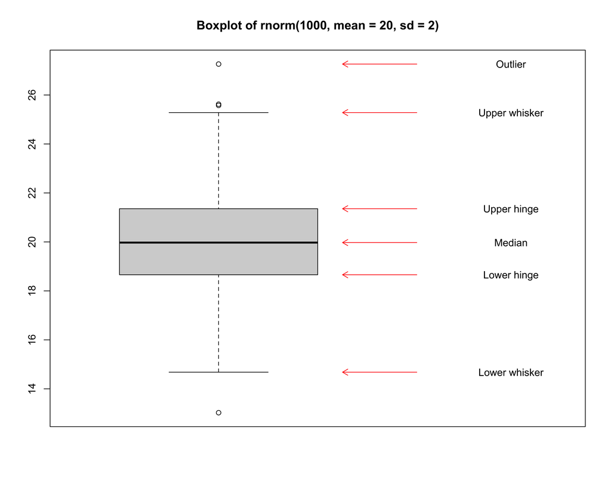

## Boxplots

Useful to Compare observations from 2 or more groups

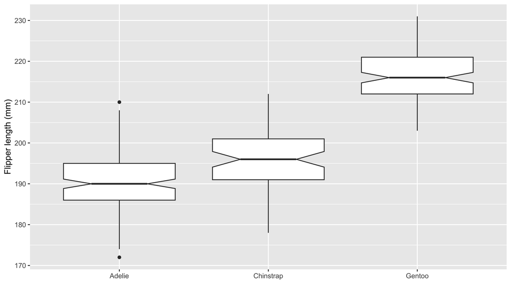

## Histograms

Histograms; a graphical representation of the frequency or density distribution of data

- Data are assigned to determined bins
- Values of a discrete variable usually determine the bins
- Number of bins is determined by the bin width
- Area under a histogram sums to 1 for histogram showing densities
- Often, histograms drawn as frequency histograms; area no longer sums to 1

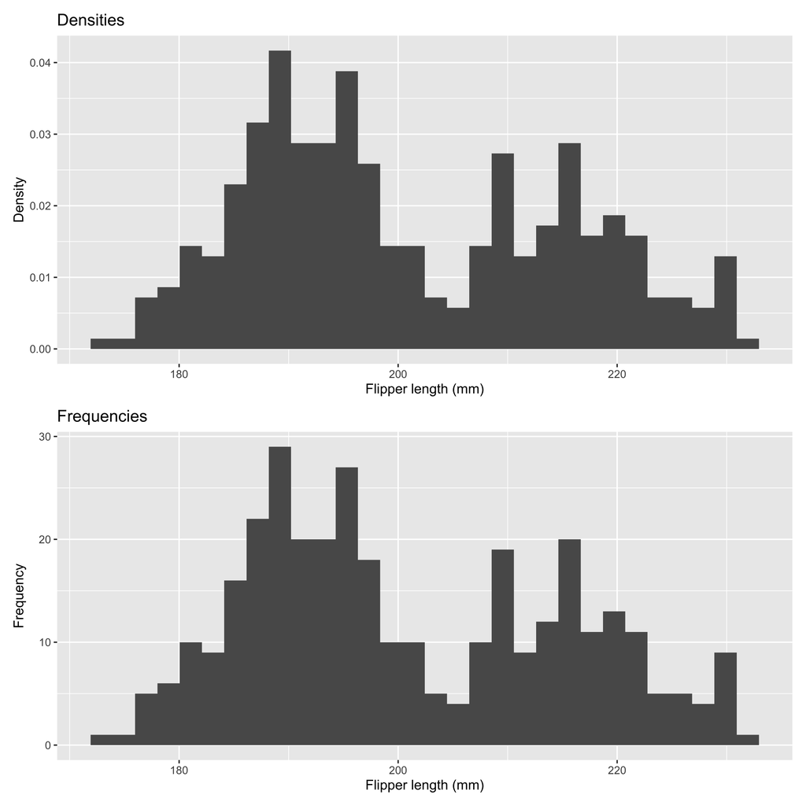

## Histograms

Choosing the bin width is a critical step in drawing a histogram<sup>1</sup>

- $k = \sqrt{n}$
- Sturge’s: $k = \frac{\mathrm{range}(x)}{(\log_2n + 1)}$
- Scott’s: $k = \frac{3.49\hat{\sigma}}{n^{1/3}}$
- Freedman-Diaconis: $k = 2 \frac{\mathrm{IQR}(x)}{n^{1/3}}$

$\hat{\sigma}$ is the estimated SD, $n$ number of observations, & $\mathrm{IQR}$ the interquartile range

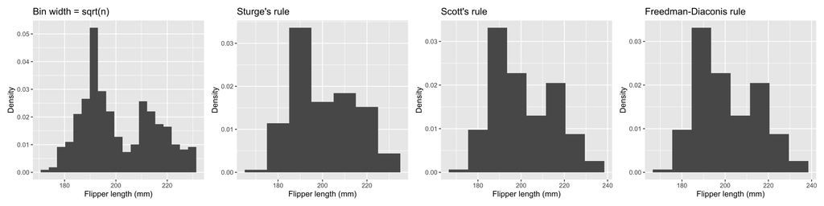

[^1]: Wand 1997 *American Statistician* 51(1) 59–64, Venables & Ripley (2001) *Modern Applied Statistics with S*

## Quantile-Quantile plots

Quantile-quantile (QQ) plots are useful to determine if a sample is normally distributed

Draws quantiles of the data & a reference distribution. If normally distributed, points should fall on line through upper & lower quartiles of both distributions

100 random draws from a $t_3$ distribution — heavy tails compared to normal

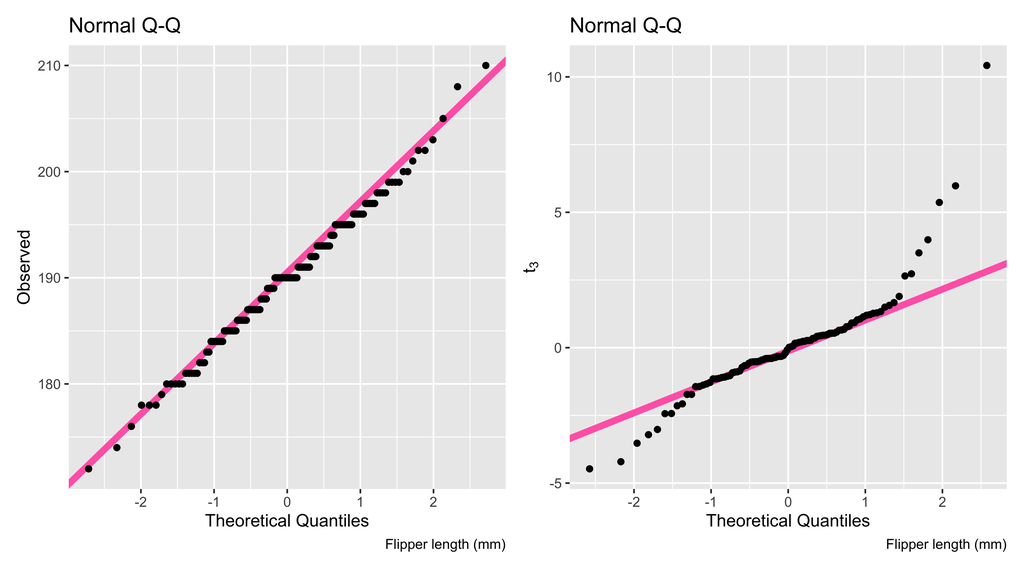

## Scatterplots

Thus far dealt only with univariate data displays. Other displays needed for bivariate and multivariate data

A scatterplot displays the relationship between two variables, $x$ and $y$ say

Each point on the plot represents the value of $x_i$ and $y_i$ for a single observation $i$

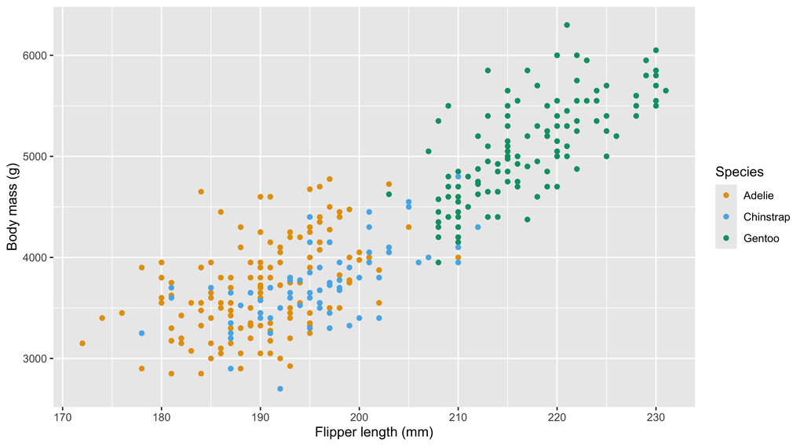

## Simpson’s paradox

Important to plot data so you aren’t surprised when you model it

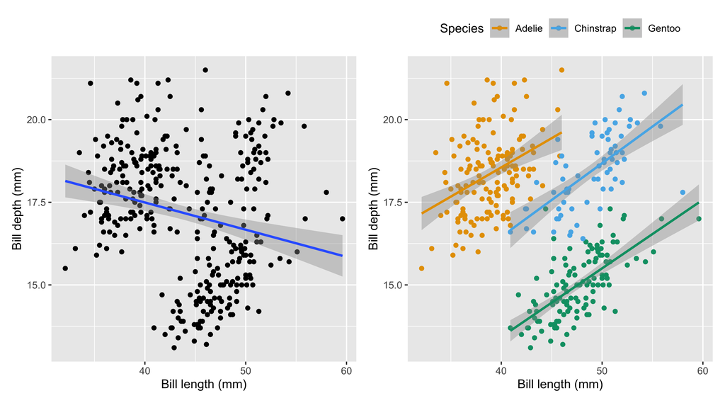

## Transformations

Linear least squares regression makes some strong assumptions about your data; often these don’t hold

*All hope abandon ye who enter here*?

Often a transformation of the data can make them follow the assumptions more closely — though there are better ways

Transformation also play an important role in EDA

## Transformations

Powers & roots are a useful set of transformations: $x \rightarrow x^p$

If $p$ is positive have a *power* transformation; $p$ negative we have an inverse power

If $p$ is a fraction we have a root transformation

- **p = 2**: power transformation
- **p = -1**: power (inverse) transformation
- **p = 0.5**: square root transformation
- **p = 1/3**: cube root transformation
- **p = 0**: convention dictates this is the log transformation

## Transforming skewness

Highly skewed distributions are difficult to explore because most of the data is scrunched up at one end of the distribution

Descend ladder of powers & roots to $\mathsf{\log(x)}$, pulls in right tail. Ascending the ladder does the opposite; pulls in left tail is data negatively skewed

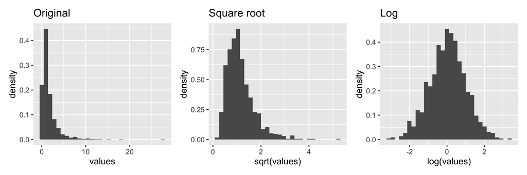

## Transforming nonlinearity

Transformation can help render many types of nonlinear relationships roughly linear

Clear that we are thinking about pairs of variables here; $x$ and $y$

Need to choose whether to transform $y$, $x$, or both?

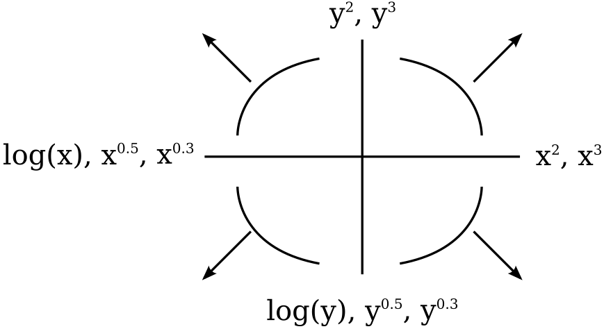

## Transforming nonlinearity

New York air quality data & various transformation to linearise bivariate relationship

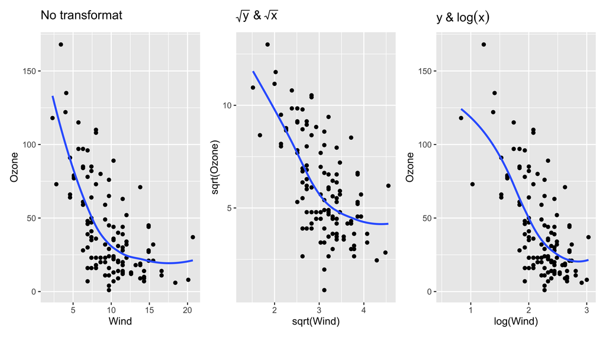